# HO1-DSP

**A. Membuat gelombang sinus dan cosinus**

- Buat array t yang berkisar dari 0 hingga 2 dengan langkah sebesar 0.0001.

  Pertama, import library yang akan digunakan.

```python
import numpy as np
import matplotlib.pyplot as plt
```

Kemudian kita membuat array dengan ketentuan pada soal.

```python
t = np.arange(0, 2, 0.0001)
print(t)
```

```
[0.0000e+00 1.0000e-04 2.0000e-04 ... 1.9997e+00 1.9998e+00 1.9999e+00]
```

- Buat sinyal-sinyal menggunakan array waktu ini:
1. $y1 = 2 \cdot \sin(2 \pi \cdot 3 \cdot t + 0)$
2. $y2 = 1 \cdot \cos(2 \pi \cdot 4 \cdot t + \pi/4)$
3. $y3 = -1 \cdot \sin(2 \pi \cdot 5 \cdot t + \pi/2)$
4. $y1 = 0.5 \cdot \cos(2 \pi \cdot 6 \cdot t + \pi)$

```python
y1 = 2 * np.sin(2 * np.pi * 3 * t + 0)
y2 = 1 * np.cos(2 * np.pi * 4 * t + np.pi / 4)
y3 = -1 * np.sin(2 * np.pi * 5 * t + np.pi / 2)
y4 = 0.5 * np.cos(2 * np.pi * 6 * t + np.pi)
```

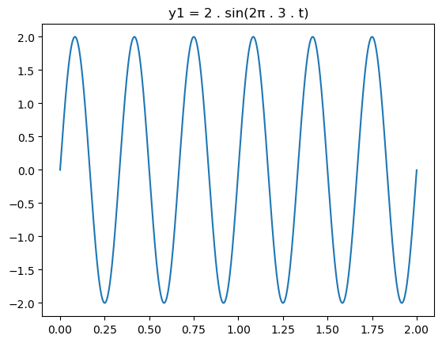

```python
plt.plot(t, y1)
plt.title('y1 = 2 . sin(2π . 3 . t)')
plt.show()
```

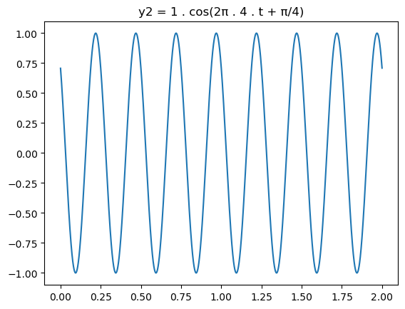

```python
plt.plot(t, y2)
plt.title('y2 = 1 . cos(2π . 4 . t + π/4)')
plt.show()
```

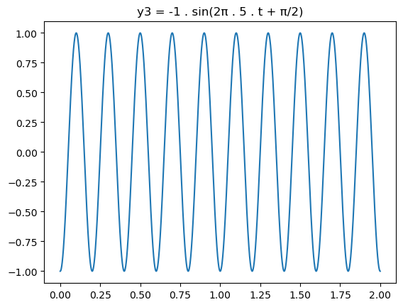

```python
plt.plot(t, y3)
plt.title('y3 = -1 . sin(2π . 5 . t + π/2)')
plt.show()
```

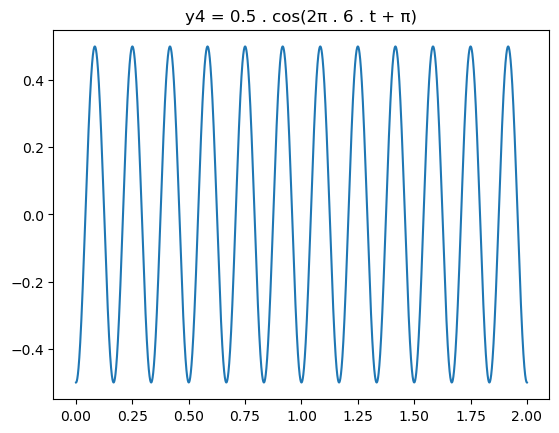

```python
plt.plot(t, y4)
plt.title('y4 = 0.5 . cos(2π . 6 . t + π)')
plt.show()
```

**B. Perbandingan subplot**

- Buat gambar dengan 4 subplot (grid 2x2) untuk membandingkan semua sinyal secara berdampingan.
- Setiap subplot harus berisi salah satu sinyal ( y1 ), ( y2 ), ( y3 ), dan ( y4 ).

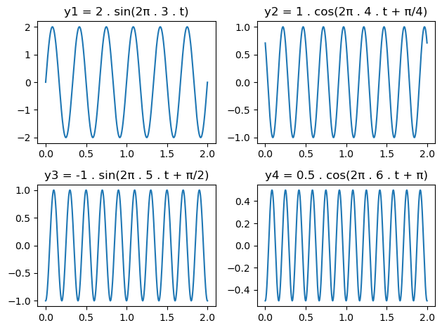

```python
plt.subplot(2, 2, 1)
plt.plot(t, y1)
plt.title('y1 = 2 . sin(2π . 3 . t)')

plt.subplot(2, 2, 2)
plt.plot(t, y2)
plt.title('y2 = 1 . cos(2π . 4 . t + π/4)')

plt.subplot(2, 2, 3)
plt.plot(t, y3)
plt.title('y3 = -1 . sin(2π . 5 . t + π/2)')

plt.subplot(2, 2, 4)
plt.plot(t, y4)
plt.title('y4 = 0.5 . cos(2π . 6 . t + π)')

plt.tight_layout() #menambahkan spasi agar subplot tidak tumpang tindih
plt.show()
```

**C. Pertanyaan analisis**

1. Berapa amplitudo dan frekuensi masing-masing sinyal?
2. Bagaimana pergeseran fase mempengaruhi posisi gelombang? (Anda dapat mengubah nilai fase pada sinyal-sinyal yang telah dibuat sesuka anda)
3. Bandingkan sinyal-sinyal dengan amplitudo yang berbeda dan diskusikan bagaimana amplitudo mempengaruhi tampilan gelombang.
4. Bandingkan sinyal-sinyal dengan pergeseran fase yang berbeda dan diskusikan bagaimana pergeseran fase mempengaruhi tampilan gelombang.

Jawaban:

1. Berikut adalah amplitudo dan frekuensi masing-masing sinyal:
   - y1: amplitudo = 2, frekuensi = 3
   - y2: amplitudo = 1, frekuensi = 4
   - y3: amplitudo = -1, frekuensi = 5
   - y4: amplitudo = 0.5, frekuensi = 6
2. Pengaruh pergeseran fase pada gelombang:

   Pergeseran fase pada gelombang mempengaruhi posisi awal gelombang tanpa mengubah bentuknya. Jika fase awal bernilai positif, gelombang akan bergeser ke kiri, menandakan bahwa gelombang tersebut lebih cepat dari keadaan normal. Sebaliknya, jika fase awal bernilai negatif, gelombang akan bergeser ke kanan, yang berarti gelombang mengalami keterlambatan. Perhatikan grafik perbandingan pada y1 berikut.

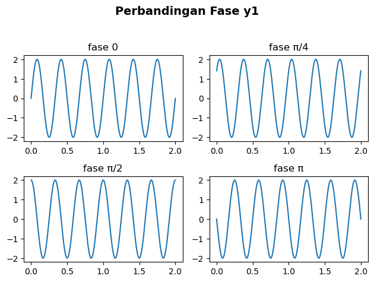

```python
y1 = 2 * np.sin(2 * np.pi * 3 * t + 0)
y1_pi4 = 2 * np.sin(2 * np.pi * 3 * t + np.pi / 4)
y1_pi2 = 2 * np.sin(2 * np.pi * 3 * t + np.pi / 2)
y1_pi = 2 * np.sin(2 * np.pi * 3 * t + np.pi)

plt.subplot(2, 2, 1)
plt.plot(t, y1)
plt.title('fase 0')

plt.subplot(2, 2, 2)
plt.plot(t, y1_pi4)
plt.title('fase π/4')

plt.subplot(2, 2, 3)
plt.plot(t, y1_pi2)
plt.title('fase π/2')

plt.subplot(2, 2, 4)
plt.plot(t, y1_pi)
plt.title('fase π')

plt.tight_layout()

plt.suptitle("Perbandingan Fase y1", fontsize=14, fontweight="bold")
plt.tight_layout(rect=[0, 0, 1, 0.95])
plt.show()
```

3. Perbandingan sinyal dengan amplitudo berbeda:

   Amplitudo adalah tinggi maksimum gelombang dari titik keseimbangan. Berdasarkan grafik di bawah, dapat disimpulkan bahwa semakin besar amplitudo, semakin kuat gelombang yang dihasilkan. Artinya, puncak dan lembah gelombang akan semakin tinggi dan semakin dalam saat amplitudo bertambah.

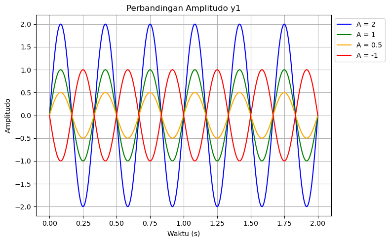

```python
y1 = 2 * np.sin(2 * np.pi * 3 * t + 0)
y1_2 = 1 * np.sin(2 * np.pi * 3 * t + 0)
y1_3 = 0.5 * np.sin(2 * np.pi * 3 * t + 0)
y1_4 = -1 * np.sin(2 * np.pi * 3 * t + 0)

plt.figure(figsize=(8, 5))
plt.plot(t, y1, label="A = 2", color="blue")
plt.plot(t, y1_2, label="A = 1", color="green")
plt.plot(t, y1_3, label="A = 0.5", color="orange")
plt.plot(t, y1_4, label="A = -1", color="red")

plt.title("Perbandingan Amplitudo y1")
plt.xlabel("Waktu (s)")
plt.ylabel("Amplitudo")

plt.grid(True)

plt.legend(loc="upper left", bbox_to_anchor=(1, 1))

plt.tight_layout()

plt.show()
```

4. Perbandingan fase pada gelombang:

   Keempat persamaan gelombang tersebut memiliki bentuk dasar yang sama, yaitu gelombang sinusoidal dengan amplitudo 2 dan frekuensi 3 Hz. Namun, perbedaannya terletak pada pergeseran fase yang mempengaruhi posisi awal gelombang dalam siklusnya.
   - $y1 = 2 \cdot \sin(2 \pi \cdot 3 \cdot t + 0)$
     - Gelombang ini adalah gelombang awal tanpa pergeseran fase.
     - Dimulai dari nol saat dan mengikuti pola sinus normal.
   - $y1 = 2 \cdot \sin(2 \pi \cdot 3 \cdot t + \pi/4)$
     - Pergeseran fase sebesar 45 derajat menyebabkan gelombang bergeser ke kiri
     - Gelombang ini lebih cepat dibandingkan gelombang awal
   - $y1 = 2 \cdot \sin(2 \pi \cdot 3 \cdot t + \pi/2)$
     - Pergeseran fase sebesar 90 derajat menyebabkan gelombang bergeser ke kiri
   - $y1 = 2 \cdot \sin(2 \pi \cdot 3 \cdot t + \pi)$
     - Pergeseran fase sebesar 180 derajat menyebabkan gelombang bergeser ke kiri
     - Gelombang ini berada dalam kondisi berlawanan dengan gelombang awal, artinya setiap nilai positif pada gelombang awal akan bernilai negatif pada gelombang ini, vice versa.

   **Kesimpulan:**

   Pergeseran fase mempengaruhi posisi dan mempengaruhi cepat lambat gelombang. Semakin besar pergeseran fase, semakin jauh posisi gelombang bergeser ke kiri. Pergeseran fase sebesar π menghasilkan gelombang yang sepenuhnya berlawanan dengan gelombang awal.

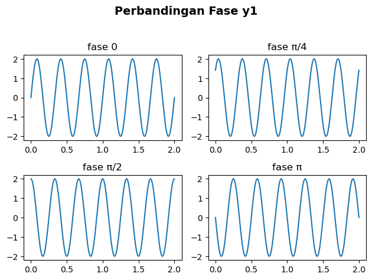

```python
y1 = 2 * np.sin(2 * np.pi * 3 * t + 0)
y1_pi4 = 2 * np.sin(2 * np.pi * 3 * t + np.pi / 4)
y1_pi2 = 2 * np.sin(2 * np.pi * 3 * t + np.pi / 2)
y1_pi = 2 * np.sin(2 * np.pi * 3 * t + np.pi)

plt.subplot(2, 2, 1)
plt.plot(t, y1)
plt.title('fase 0')

plt.subplot(2, 2, 2)
plt.plot(t, y1_pi4)
plt.title('fase π/4')

plt.subplot(2, 2, 3)
plt.plot(t, y1_pi2)
plt.title('fase π/2')

plt.subplot(2, 2, 4)
plt.plot(t, y1_pi)
plt.title('fase π')

plt.tight_layout()

plt.suptitle("Perbandingan Fase y1", fontsize=14, fontweight="bold")
plt.tight_layout(rect=[0, 0, 1, 0.95])
plt.show()
```

**D. Tugas lanjutan**

- Buat sinyal baru y5 yang merupakan kombinasi dari y1 dan y2, yaitu y5 = y1 + y2
- plot y5 dan diskusikan bagaimana kombinasi dua gelombang sinus/cosinus mempengaruhi bentuk gelombang yang dihasilkan!

  Jawaban:

  y1 merupakan gelombang sinus dan y2 merupakan gelombang cosinus. Ketika digabungkan dalam gelombang y5, terlihat bahwa grafik y5 sangat berbeda jauh dengan grafik induknya (y1 dan y2) alias tidak lagi berupa grafik sinus dan cosinus sederhana. Hal ini dapat dipengaruhi oleh beberapa faktor, yaitu:
  - Perbedaan frekuensi antara grafik induk (y1 dan y2). Ketika dua gelombang dengan frekuensi berbeda dijumlahkan, maka pola gelombang baru yang dihasilkan menjadi berubah.
  - Adanya interferensi. Amplitudo dari gelombang y5 akan berubah-ubah di sepanjang waktu karena terjadi modulasi amplitudi akibat selisih frekuensi. Ketika gelombang bertemu dalam fase konstruktif, amplitudo akan meningkat. Sementara ketika bertemu dalam fase destruktif, amplitudo menurun.
  - Perbedaan fase pada gelombang induk. Gelombang y1 dimulai dari 0 sementara y2 pada π/4 sehingga titik awal kedua gelombang tidak sejajar. Ketidaksejajaran ini tidak hanya menyebabkan gelombang y5 mengalami perubahan amplitudo tetapi juga pergeseran/perubahan bentuk.

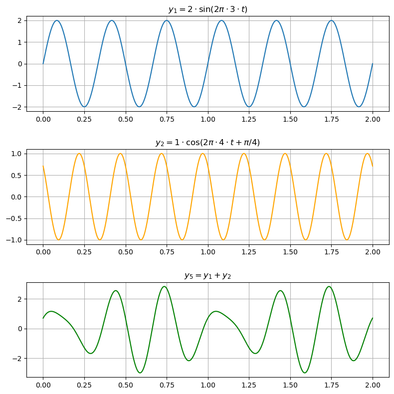

```python
y1 = 2 * np.sin(2 * np.pi * 3 * t + 0)
y2 = 1 * np.cos(2 * np.pi * 4 * t + np.pi / 4)
y5 = y1 + y2

plt.figure(figsize=(8, 8))

plt.subplot(3, 1, 1)
plt.plot(t, y1, label=r"$y_1 = 2 \cdot \sin(2\pi \cdot 3 \cdot t)$")
plt.title(r"$y_1 = 2 \cdot \sin(2\pi \cdot 3 \cdot t)$")
plt.grid()

plt.subplot(3, 1, 2)
plt.plot(t, y2, label=r"$y_2 = 1 \cdot \cos(2\pi \cdot 4 \cdot t + \pi/4)$", color="orange")
plt.title(r"$y_2 = 1 \cdot \cos(2\pi \cdot 4 \cdot t + \pi/4)$")
plt.grid()

plt.subplot(3, 1, 3)
plt.plot(t, y5, label=r"$y_5 = y_1 + y_2$", color="green")
plt.title(r"$y_5 = y_1 + y_2$")
plt.grid()

plt.tight_layout()
plt.subplots_adjust(hspace=0.4)

plt.show()
```

# REFERENSI

[Link percakapan](https://chatgpt.com/share/67e2c895-e00c-8012-9915-523f31c5faa9)